# Visualizing Big Datasets

Rasterization and Datashader

### Looking Back

- Distributed data processing with Apache Spark
- Out-of-core computation with Dask
- Large datasets stored on Amazon S3
- The challenge: analysis pipelines that produce millions of output rows

### Today

- Why standard plotting libraries fail at 10M+ rows
- The rasterization pipeline — pixels as statistics
- Datashader: aggregation-first visualization
- Integration with Dask, HoloViews, and Panel
- Connecting Datashader to a Spark pipeline

## Agenda

### Part 1: The Rasterization Pipeline

- Why matplotlib breaks at scale
- The rasterization pipeline concept
- Datashader: aggregations, colormaps, interactivity

### Part 2: Datashader + Spark

- Where visualization fits in a Spark workflow
- Two bridging patterns: pandas vs. Dask
- Visualizing Spark MLlib outputs

# The Rasterization Pipeline

## The Problem: Why Standard Plots Break

- `matplotlib` / `seaborn` render **one mark per data point** — fine at N = 10K, broken at N = 10M+
- Memory: a 10M-point scatter plot can consume several GB before a pixel is drawn
- Overplotting hides structure — dense regions look identical to sparse ones
- **The solution**: don’t plot points, plot *statistics of pixels*

## The Rasterization Strategy

**Traditional pipeline**

```
data (N rows)
  → geometry (N shapes)
    → render (N draw calls)
      → screen pixels
```

Bottleneck is proportional to **N**

**Rasterization pipeline**

```
data (N rows)
  → canvas grid (W × H bins)
    → aggregate into bins
      → colormap bins → pixels
```

Bottleneck is proportional to **W × H** (fixed)

> Key insight: the screen has a fixed resolution. Aggregate to pixels *before* rendering, not after.

## How Datashader Works

```
flowchart LR
  A[DataFrame <br> N rows] --> B[Canvas <br> W×H grid]
  B --> C[Aggregate <br> count / mean / sum…]
  C --> D[Transfer <br> function / colormap]
  D --> E[Image <br> W×H pixels]
```

```
flowchart LR
  A[DataFrame <br> N rows] --> B[Canvas <br> W×H grid]
  B --> C[Aggregate <br> count / mean / sum…]
  C --> D[Transfer <br> function / colormap]
  D --> E[Image <br> W×H pixels]
```

1. **Canvas** — define a pixel grid mapped to data coordinates
2. **Aggregate** — reduce all points that fall in each pixel to a scalar (default: `count`)
3. **Transfer function** — map aggregates to colors (linear, log, eq-hist)
4. **Embed** — return a PNG/RGBA image for display in Jupyter, Bokeh, or HoloViews

## Datashader: Minimal Example

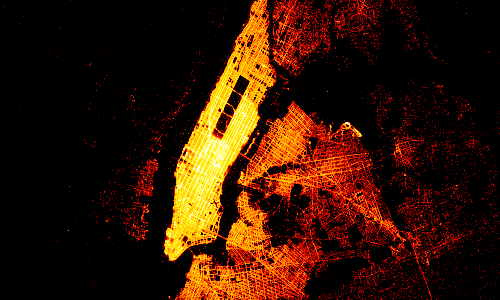

```python
import datashader as ds, colorcet as cc
import hvsampledata as hvs

df = hvs.nyc_taxi_remote("pandas", engine_kwargs={"columns": ['dropoff_x', 'dropoff_y']})

canvas = ds.Canvas(plot_width=500, plot_height=300)
agg = canvas.points(df, 'dropoff_x', 'dropoff_y')
ds.tf.set_background(ds.tf.shade(agg, cmap=cc.fire), "black")
```

- Plotting 11,842,094 dropoff locations in NYC
- What’s being plotted is the total number of dropoffs at locations within each pixel on this canvas
- This aggregate is then being mapped to colors on a colorscale
- It’s using latitude and longitude, but without much context
- Works with **pandas**, **Dask**, **cuDF** (NVIDIA’s GPU-accelerated DataFrame library), **Polars** (via Arrow)
- No data is sent to the browser — only the final W×H image

The NYC Taxi data used here is derivative of the other yellow taxi data we’ve used this semester

## Datashader: Contexualizing the visualization

```python
import holoviews as hv
from holoviews.element.tiles import EsriImagery
from holoviews.operation.datashader import datashade
hv.extension('bokeh')

map_tiles  = EsriImagery().opts(alpha=0.5, width=900, height=480, bgcolor='black')
points     = hv.Points(df, ['dropoff_x', 'dropoff_y'])
taxi_trips = datashade(points, x_sampling=1, y_sampling=1, cmap=cc.fire, width=900, height=480)

map_tiles * taxi_trips
```

[output not shown]

ⓘ

We can put our visualization on top of a map, for example. Maps are often provided as raster graphics.

## Aggregation Reductions

| Reduction | Code | Use case |
| --- | --- | --- |
| Point count | `ds.count()` | density maps |
| Numeric mean | `ds.mean("value")` | spatial averages |
| Any/first value | `ds.any()`, `ds.first("col")` | categorical presence |
| Count-distinct | `ds.count_cat("category")` | multi-class overlays |
| Min / Max | `ds.min()`, `ds.max()` | range surfaces |

Default is `count()` — most visualizations start here.